# Machine Learning for Macroeconomics - Project

Éloïse Leroux, Matthieu Grenier, Matteo van Ypersele

31/01/2025

### Required Packages

Run the following code to install the necessary packages if they are not already installed.

```r
install.packages("stats")
install.packages("readr")
install.packages("pracma")
install.packages("devtools")
install.packages("glmnet")
library(devtools)
devtools::install_github("cykbennie/fbi")
install.packages("BVAR")
```

### Introduction

This script compares three forecasting methods seen in class to predict inflation in France:

1. **LASSO** (Least Absolute Shrinkage and Selection Operator)
2. **Random Forest** (Machine Learning)
3. **PCA + OLS** (Principal Component Analysis followed by a linear regression)

The dataset used for the forecast comes from the EA-MD-QD collection. The raw data has already been processed by a Matlab code, available in the Github. The sheet we used here is `FRdataM_LT.xlsx`. Its variables are monthly observations of various french indicators.

The forecast we aim to propose covers a **12-month horizon**.

###Data processing

```r
#Imports
library(BVAR)
library(glmnet)
library(readxl)
library(purrr)
library(dplyr)
library(randomForest)
library(ggplot2)
```

```r
current_directory <- dirname(rstudioapi::getSourceEditorContext()$path)
setwd(current_directory)
```

### 📌 Data loading and processing

```r
file_path <- 'data/FRdataM_LT.xlsx'
data <- read_excel(file_path)

data$Time <- as.Date(data$Time)#Proper date format

y_inflationglobale <- ts(data$HICPOV_FR, start = c(2000, 1), frequency = 12)

excluded_cols <- c("Time", "HICPOV_FR", "HICPNEF_FR", "HICPG_FR", "HICPIN_FR",
                   "HICPNG_FR", "PPICAG_FR", "PPICOG_FR", "PPINDCOG_FR",
                   "PPIDCOG_FR", "PPIING_FR", "PPINRG_FR")
X <- as.matrix(data[, !(names(data) %in% excluded_cols)])

data <- data[-nrow(data), ]#The last row has too much missing values

start_date <- "2000-02-01"
start_sample <- which(data$Time == start_date)
```

At this point, the data is ready for forecasting. The following graph represents the outcome variable, distinguishing the test and the training set.

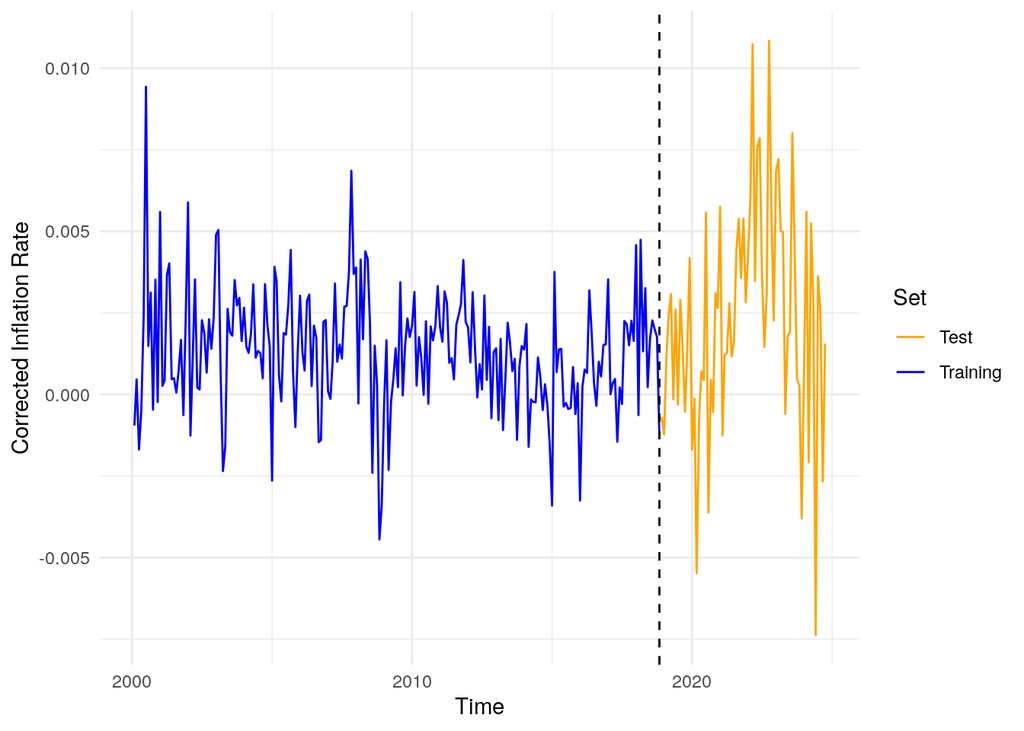

```r
start_sample <- 226

train_end <- data$Time[start_sample]
data$Set <- ifelse(data$Time <= train_end, "Training", "Test")

ggplot(data, aes(x = Time, y = HICPOV_FR, color = Set)) +
  geom_line() +
  geom_vline(xintercept = as.numeric(train_end), linetype = "dashed", color = "black") +
  scale_color_manual(values = c("Training" = "blue", "Test" = "orange")) +
  labs(x = "Time", y = "Corrected Inflation Rate", color = "Set") +
  theme_minimal()
```

### 📌 Tuning parameters

Two tuning parameters are considered : - ‘HH’ is the forecast horizon in months - ‘DEMEAN’ allows to control standardisation and normalisation

```r
DEMEAN <- 2   # 2 : Standardisation
HH <- 12      # Forecast horizon
```

The use of the `DEMEAN` parameter might be clearer with the following function :

```r
transform_data <- function(x, DEMEAN) {
  x[is.na(x)] <- colMeans(x, na.rm = TRUE)[col(x)[is.na(x)]]  # Replaces NAs
  x <- x[, colSums(!is.na(x)) > 0]  # Deletes empty columns

  if (DEMEAN == 1) {
    return(scale(x, center = TRUE, scale = FALSE))
  } else if (DEMEAN == 2) {
    return(scale(x, center = FALSE, scale = TRUE))
  } else if (DEMEAN == 3) {
    return(scale(x, center = TRUE, scale = TRUE))
  }
  return(x)
}
```

## 📌 Models

The following functions are used to fit all of our models.

### 1️⃣ PCA + OLS

```r
PCA_OLS_regression <- function(y, X, kmax = 8) {
  X_scaled <- transform_data(X, DEMEAN)

  # PCA using SVD
  svd_result <- svd(X_scaled)
  Fhat <- svd_result$u[, 1:kmax]  # k first factors are considered

  # OLS regression on the principal components
  Fhat_k <- cbind(1, Fhat)
  ols_model <- lm(y ~ ., data = as.data.frame(Fhat_k))

  # Prédiction
  pred <- predict(ols_model, newdata = as.data.frame(tail(Fhat_k, 1)))

  return(list(pred = pred, model = ols_model))
}
```

### 2️⃣ LASSO

```r
Lasso_regression <- function(yy, x, DEMEAN) {
  # Smoothing of the outcome value
  Y <- stats::filter(yy, filter = rep(1/HH, HH), sides = 1)

  # NA values check
  if (any(rowSums(is.na(x)) == ncol(x))) {
    stop("x has an empty row")
  }

  # Empty columns are replaced/deleted
  Index_missing <- which(colSums(is.na(x)) == nrow(x))
  Index_zeros <- which(colSums(x == 0) == nrow(x))
  Index_remove <- unique(c(Index_missing, Index_zeros))

  if (length(Index_remove) > 0) {
    x <- subset(x, select = -Index_remove)
  }

  # Check on the DEMEAN parameter
  if (!(DEMEAN %in% 0:3)) {
    stop("DEMEAN is incorrectly specified")
  }

  # Missing values are replaced with the mean value of each column
  mut <- matrix(rep(colMeans(x, na.rm = TRUE), nrow(x)), nrow = nrow(x), ncol = ncol(x), byrow = TRUE)
  x[is.na(x)] <- mut[is.na(x)]

  # Standardisation
  x <- transform_data(x, DEMEAN)

  # Further cheks of null columns
  Index_zeros <- which(colSums(x == 0) == nrow(x))
  if (length(Index_zeros) > 0) {
    x <- subset(x, select = -Index_zeros)
  }

  # Regression matrices and standardisation of the outcome variable
  Z <- as.matrix(x[1:(nrow(x) - HH), ])
  Y <- as.matrix(Y[(HH + 1):length(Y)])

  my <- colMeans(Y, na.rm = TRUE)
  sy <- sd(Y, na.rm = TRUE) / sqrt(length(Y))
  Y_std <- (Y - my) / sy

  # Lasso regression
  cv.m <- cv.glmnet(Z, Y_std, alpha = 1)

  # Forecast
  pred <- predict(cv.m, newx = tail(Z, 1))
  prediction <- pred * sy + my

  return(list(pred = prediction, model = cv.m))
}
```

### 3️⃣ Random Forest

```r
Random_Forest_regression <- function(yy, x, DEMEAN) {
  #USUAL CHECKS
  # NA values check
  if (any(rowSums(is.na(x)) == ncol(x))) {
    stop("x has an empty row")
  }

  # Empty columns are replaced/deleted
  Index_missing <- which(colSums(is.na(x)) == nrow(x))
  Index_zeros <- which(colSums(x == 0) == nrow(x))
  Index_remove <- unique(c(Index_missing, Index_zeros))

  if (length(Index_remove) > 0) {
    x <- subset(x, select = -Index_remove)
  }

  # Check on the DEMEAN parameter
  if (!(DEMEAN %in% 0:3)) {
    stop("DEMEAN is incorrectly specified")
  }

  # Missing values are replaced with the mean value of each column
  mut <- matrix(rep(colMeans(x, na.rm = TRUE), nrow(x)), nrow = nrow(x), ncol = ncol(x), byrow = TRUE)
  x[is.na(x)] <- mut[is.na(x)]

  # Standardisation
  x <- transform_data(x, DEMEAN)

  # Further cheks of null columns
  Index_zeros <- which(colSums(x == 0) == nrow(x))
  if (length(Index_zeros) > 0) {
    x <- subset(x, select = -Index_zeros)
  }

  # Regression matrices and standardisation of the outcome variable
  Z <- as.matrix(x[1:(nrow(x) - HH), ])
  Y <- as.matrix(yy[(HH + 1):length(yy)])

  my <- colMeans(Y, na.rm = TRUE)
  sy <- sd(Y, na.rm = TRUE) / sqrt(length(Y))
  Y_std <- (Y - my) / sy


  rf.fit <- randomForest(Z,Y_std,ntree=500,mtry=20,importance=TRUE)

  # Forecast
  pred <- predict(rf.fit, newx = tail(Z, 1))
  prediction <- pred * sy + my

  return(list(pred = prediction, model = rf.fit))
}
```

## 📌 Forecast

The forecast methods are implemented using rollin window forecasting, that is to say that each forecast uses models fit on a given window of previous observations.

```r
# Matrices to store the results
TT <- nrow(data)
start_sample <- 226
true <- rep(NA, TT - start_sample)
Lasso <- rep(NA, TT - start_sample)
RandomForest <- rep(NA, TT - start_sample)
PCA_OLS <- rep(NA, TT - start_sample)

for (j in start_sample:(TT - HH)) {
  j0 <- max(1, j - start_sample + 1)

  x_temp <- X[j0:j, ]
  y_temp <- y_inflationglobale[j0:j]

  # Lasso
  result_Lasso <- Lasso_regression(y_temp, x_temp, DEMEAN)
  Lasso[j - start_sample + 1] <- result_Lasso$pred

  # RF
  result_RF <- Random_Forest_regression(y_temp, x_temp, DEMEAN)
  RandomForest[j - start_sample + 1] <- result_RF$pred

  #PCA+OLS
  result_PCA_OLS <- PCA_OLS_regression(y_temp, x_temp)
  PCA_OLS[j - start_sample + 1] <- result_PCA_OLS$pred

  # True value
  true[j - start_sample + 1] <- y_inflationglobale[j + HH]
}

#NAs error handling
Index_valid <- which(!is.na(true) & !is.na(PCA_OLS) & !is.na(Lasso) & !is.na(RandomForest))
true_NA <- true[Index_valid]
PCA_OLS_NA <- PCA_OLS[Index_valid]
Lasso_NA <- Lasso[Index_valid]
RandomForest_NA <- RandomForest[Index_valid]
dates_OOS <- data$Time[(start_sample + 1):(TT - HH)][Index_valid]
```

Descriptive statistics can be drawn from our model selection in the dynamic forecasting loop.

## 📌 Performance comparison

The performance of models can be compared through the Mean Absolute Error (MAE) and the Mean Squared Error (MSE).

```r
MSFE_PCA_OLS <- sqrt(mean((true_NA - PCA_OLS_NA)^2))
MSFE_Lasso <- sqrt(mean((true_NA - Lasso_NA)^2))
MSFE_RF <- sqrt(mean((true_NA - RandomForest_NA)^2))

MAE_PCA_OLS <- mean(abs(true_NA - PCA_OLS_NA))
MAE_Lasso <- mean(abs(true_NA - Lasso_NA))
MAE_RF <- mean(abs(true_NA - RandomForest_NA))

tab <- data.frame(
  Méthode = c("PCA + OLS", "Lasso", "Random Forest"),
  MSFE = c(MSFE_PCA_OLS, MSFE_Lasso, MSFE_RF),
  MAE = c(MAE_PCA_OLS, MAE_Lasso, MAE_RF)
)
print(tab)
```

```
##         Méthode        MSFE         MAE
## 1     PCA + OLS 0.003897863 0.003192775
## 2         Lasso 0.003915436 0.003002410
## 3 Random Forest 0.003706741 0.002819848
```

For instance, the last fitted random forest yields the following results :

```r
result_RF$model
```

```
##
## Call:
##  randomForest(x = Z, y = Y_std, ntree = 500, mtry = 20, importance = TRUE)
##                Type of random forest: regression
##                      Number of trees: 500
## No. of variables tried at each split: 20
##
##           Mean of squared residuals: 185.5363
##                     % Var explained: 12.89
```

Similar tabs can be obtained for the Lasso model, as well as for the optimal choice of $\lambda$.

```r
result_Lasso$model
```

```
##
## Call:  cv.glmnet(x = Z, y = Y_std, alpha = 1)
##
## Measure: Mean-Squared Error
##
##      Lambda Index Measure    SE Nonzero
## min 0.01588    69   107.6 11.47      25
## 1se 0.08475    51   119.0 14.86      20
```

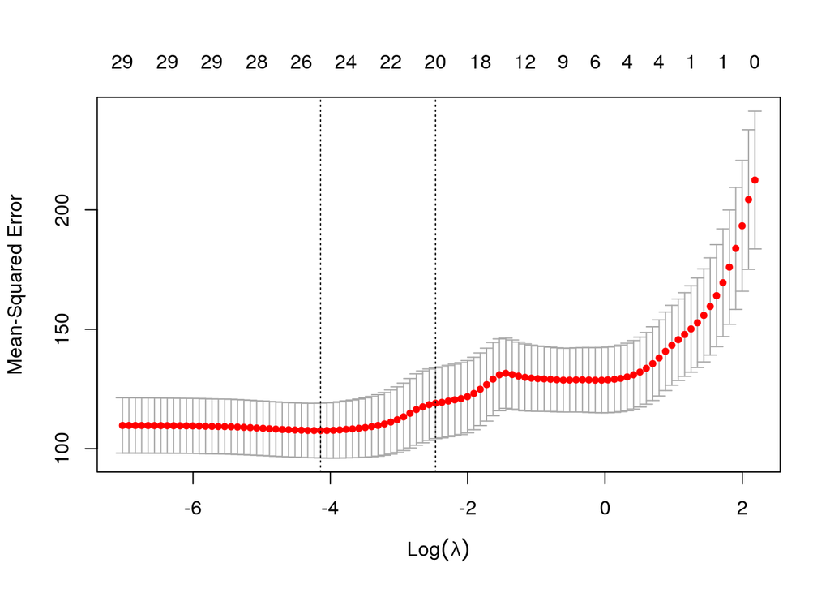

```r
plot(result_Lasso$model)
```

One can also inspect the results of the OLS on the principal components to better grasp the mechanisms used for this method to forecast.

```r
library(jtools)
summ(result_PCA_OLS$model)
```

```
## MODEL INFO:
## Observations: 226
## Dependent Variable: y
## Type: OLS linear regression
##
## MODEL FIT:
## F(8,217) = 11.43, p = 0.00
## R² = 0.30
## Adj. R² = 0.27
##
## Standard errors:OLS
## ------------------------------------------------
##                      Est.   S.E.   t val.      p
## ----------------- ------- ------ -------- ------
## (Intercept)         -0.00   0.00    -2.85   0.00
## V1
## V2                  -0.06   0.01    -4.07   0.00
## V3                  -0.06   0.02    -3.66   0.00
## V4                   0.02   0.00     5.69   0.00
## V5                  -0.01   0.00    -3.10   0.00
## V6                   0.02   0.00     6.87   0.00
## V7                   0.00   0.00     0.78   0.44
## V8                   0.00   0.00     1.08   0.28
## V9                  -0.00   0.00    -0.42   0.68
## ------------------------------------------------
```

## 📌 Forecast

Now that all of our models are fitted, one can see how inflation is predicted by each method.

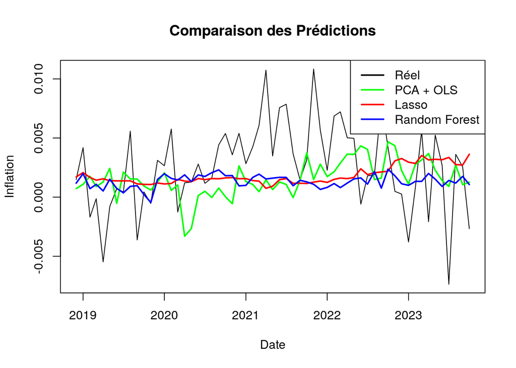

```r
plot(dates_OOS, true_NA, type = "l", col = "black", main = "Comparaison des Prédictions", xlab = "Date", ylab = "Inflation")
lines(dates_OOS, PCA_OLS_NA, col = "green", lwd = 2)
lines(dates_OOS, Lasso_NA, col = "red", lwd = 2)
lines(dates_OOS, RandomForest_NA, col = "blue", lwd = 2)
legend("topright", legend = c("Réel", "PCA + OLS", "Lasso", "Random Forest"), col = c("black", "green", "red", "blue"), lty = 1, lwd = 2)
```